# Homework 10

Arturo Alvarez

2/10/2026

## Instructions

Answer the following questions and complete the exercises in RMarkdown. Please embed all of your code and push your final work to your repository. Your final lab report should be organized, clean, and run free from errors. Remember, you must remove the `#` for the included code chunks to run. Be sure to add your name to the author header above.

Make sure to use the formatting conventions of RMarkdown to make your report neat and clean!

## Background

In the `data` folder, you will find data about shark incidents in California between 1950-2022. The [data](https://catalog.data.gov/dataset/shark-incident-database-california-56167) are from: State of California- Shark Incident Database.

## Load the libraries

```r
library("tidyverse")
library("janitor")
```

## Load the data

Run the following code chunk to import the data. In this chunk, I am removing NA’s.

```r
sharks <-
  read_csv("data/SharkIncidents_1950_2022_220302.csv",
           na=c("NA", "N/A", "Unknown", "NOT COUNTED", "", " ")) %>%
  clean_names()
```

## Questions

1. Are there any “hotspots” for shark incidents in California? Show the top five counties with the most incidents. #MAY WANT. US TO USE PIVOTS LABELED ACIS AND COLOR

[figure not shown]

```r
sharks %>%
  group_by(county) %>%
  summarise(incidents=sum(incident_num)) %>%
  ggplot(aes(x=reorder(county, -incidents), y=incidents)) +
  geom_col()+
  coord_flip()+
  labs(title="Incidents per County",
       x="County",
       y="Number Of Incidents")
```

```r
sharks %>%
summarize(sharks)
```

```
## # A tibble: 211 × 16
##    incident_num month   day  year time  county       location mode  injury depth
##           <dbl> <dbl> <dbl> <dbl> <chr> <chr>        <chr>    <chr> <chr>  <chr>
##  1            1    10     8  1950 12:00 San Diego    Imperia… Swim… major  surf…
##  2            2     5    27  1952 14:00 San Diego    Imperia… Swim… minor  surf…
##  3            3    12     7  1952 14:00 Monterey     Lovers … Swim… fatal  surf…
##  4            4     2     6  1955 12:00 Monterey     Pacific… Free… minor  surf…
##  5            5     8    14  1956 16:30 San Luis Ob… Pismo B… Swim… major  surf…
##  6            6     4    28  1957 13:30 San Luis Ob… Morro B… Swim… fatal  surf…
##  7            7    10    12  1958 <NA>  San Diego    Coronad… Swim… major  surf…
##  8            8     5     7  1959 17:30 San Francis… Baker B… Swim… fatal  surf…
##  9            9     6    14  1959 17:00 San Diego    La Jolla Free… fatal  surf…
## 10           10     7    28  1959 19:30 San Diego    La Jolla Free… minor  surf…
## # ℹ 201 more rows
## # ℹ 6 more variables: species <chr>, comment <chr>, longitude <chr>,
## #   latitude <dbl>, confirmed_source <chr>, wfl_case_number <chr>
```

2. Make a plot that shows the total number of incidents per county.

```r
names(sharks)
```

```
##  [1] "incident_num"     "month"            "day"              "year"
##  [5] "time"             "county"           "location"         "mode"
##  [9] "injury"           "depth"            "species"          "comment"
## [13] "longitude"        "latitude"         "confirmed_source" "wfl_case_number"
```

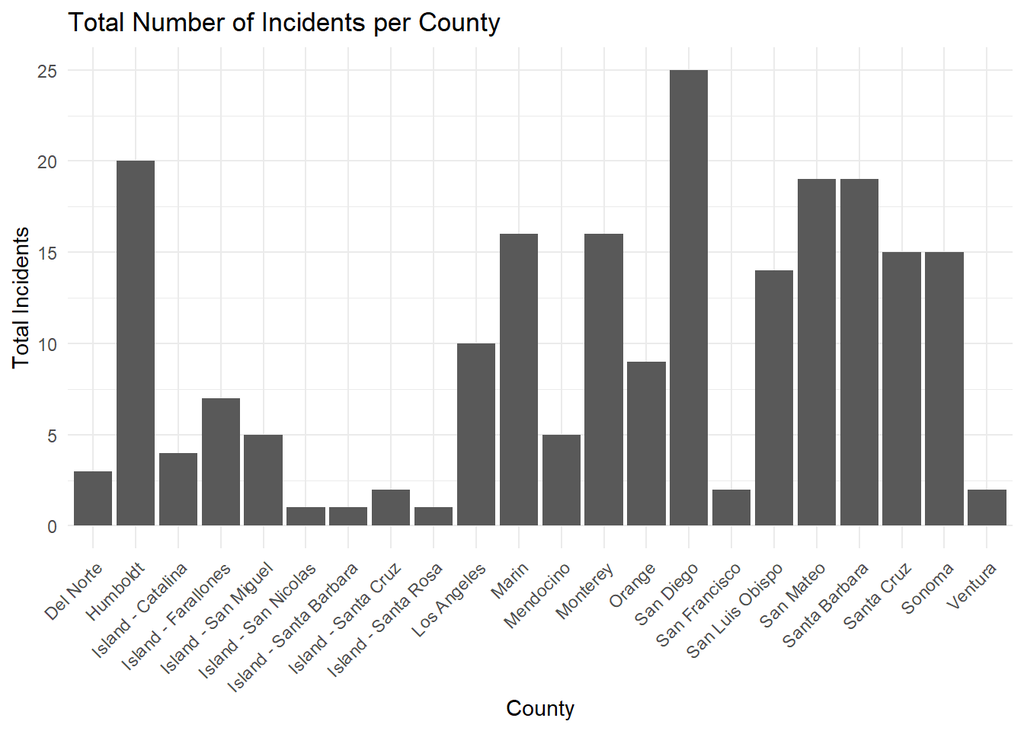

```r
county_totals <- sharks %>%
  count(county, name = "total_incidents")
ggplot(county_totals, aes(x = county, y = total_incidents)) +
  geom_col() +
  labs(
    title = "Total Number of Incidents per County",
    x = "County",
    y = "Total Incidents"
  ) +
  theme_minimal() +
  theme(axis.text.x = element_text(angle = 45, hjust = 1))
```

3. Are there months of the year when incidents are more likely to occur? Make a plot that shows the total number of incidents by month. Which month has the highest number of incidents?  
   #Fall seems to be the time of year that in incidents are most likely to occur with the 10th month of the year having the highest number of incidents.

```r
month_totals <- sharks %>%
  count(month, name = "total_incidents")
```

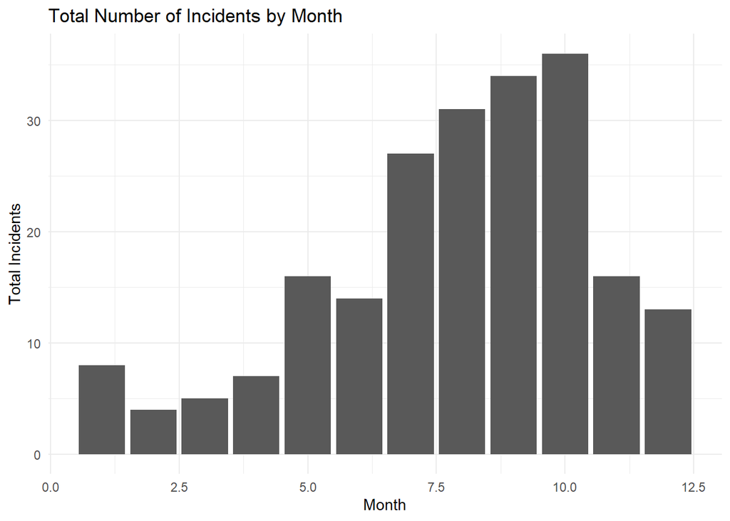

```r
ggplot(month_totals, aes(x = month, y = total_incidents)) +
  geom_col() +
  labs(
    title = "Total Number of Incidents by Month",
    x = "Month",
    y = "Total Incidents"
  ) +
  theme_minimal()
```

```r
month_totals %>%
  filter(total_incidents == max(total_incidents))
```

```
## # A tibble: 1 × 2
##   month total_incidents
##   <dbl>           <int>
## 1    10              36
```

4. Is there a time of day when most attacks occur? Make a plot that shows the total number of incidents by time of day. Which time of day has the highest number of incidents?  
   #Attacks do seem to have a higher frequency during certain times of the day, with 11:00am having the highest number of incidents in the given hour.

[figure not shown]

```r
peak_time <- sharks %>%
  filter(!is.na(time), time != "Unknown") %>%
  count(time, name = "total_incidents") %>%
  filter(total_incidents == max(total_incidents))

sharks %>%
  filter(!is.na(time), time != "Unknown") %>%
  count(time) %>%
  slice_max(n, n = 20) %>%
  ggplot(aes(x = reorder(time, -n), y = n)) +
  geom_col(fill = "pink") +
  labs(
    title = "20 Best Times of Day for Shark Incidents",
    x = "Time of Day",
    y = "Number of Incidents"
  ) +
  theme_minimal() +
  theme(axis.text.x = element_text(angle = 45, hjust = 1))
```

5. How do the number and types of injuries compare by county? Make a table that shows the number of injury types by county. Which county has the highest number incidents? (hint: your table should be in wide format)

```r
injury_table <- sharks %>%
  count(county, injury) %>%
  pivot_wider(
    names_from = injury,
    values_from = n,
    values_fill = 0
  )
sharks %>%
  count(county, name = "total_incidents") %>%
  filter(total_incidents == max(total_incidents))
```

```
## # A tibble: 1 × 2
##   county    total_incidents
##   <chr>               <int>
## 1 San Diego              25
```

6. Use the table from #5 to make a plot that shows the total number of incidents by county.

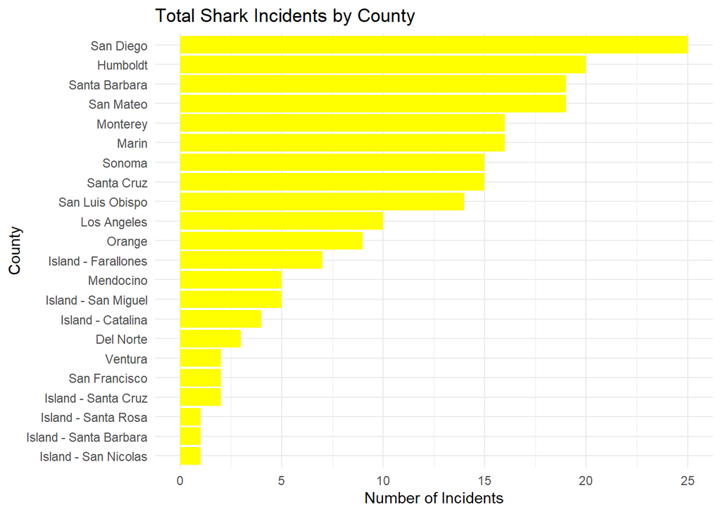

```r
sharks %>%
  count(county) %>%
  ggplot(aes(x = n, y = reorder(county, n))) +
  geom_col(fill = "yellow") +
  labs(
    title = "Total Shark Incidents by County",
    x = "Number of Incidents",
    y = "County"
  ) +
  theme_minimal()
```

7. In the data, `mode` refers to a type of activity. Which activity is associated with the highest number of incidents? #Surfing and boarding are associated with the highest number of incidents.

```r
sharks %>%
  count(mode, sort = TRUE) %>%
  slice(1)
```

```
## # A tibble: 1 × 2
##   mode                   n
##   <chr>              <int>
## 1 Surfing / Boarding    85
```

8. Make a plot that compares the number of incidents by activity.

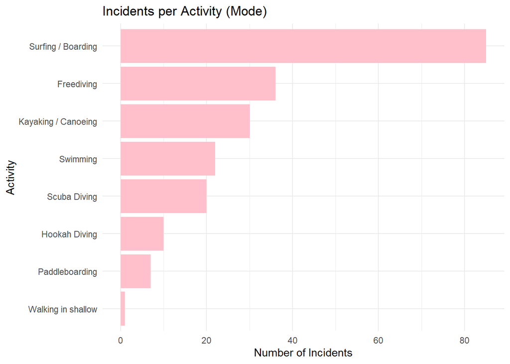

```r
sharks %>%
  count(mode) %>%
  ggplot(aes(x = n, y = reorder(mode, n))) +
  geom_col(fill = "pink") +
  labs(
    title = "Incidents per Activity (Mode)",
    x = "Number of Incidents",
    y = "Activity"
  ) +
  theme_minimal()
```

9. Which shark species is involved in the highest number of incidents?  
   #The “White” shark species is involved with the most incidents.

```r
sharks %>%
  count(species, sort = TRUE) %>%
  slice(1:5)
```

```
## # A tibble: 5 × 2
##   species          n
##   <chr>        <int>
## 1 White          181
## 2 <NA>            14
## 3 Hammerhead       3
## 4 Blue             2
## 5 Killer Whale     2
```

10. Are all incidents involving Great White’s fatal? Make a plot that shows the number and types of incidents for Great White’s only.  
    #No, many incidents involving sharks leave no injuries whatsoever, and while many havbe led to major injuries, they are mostly nonfatal.

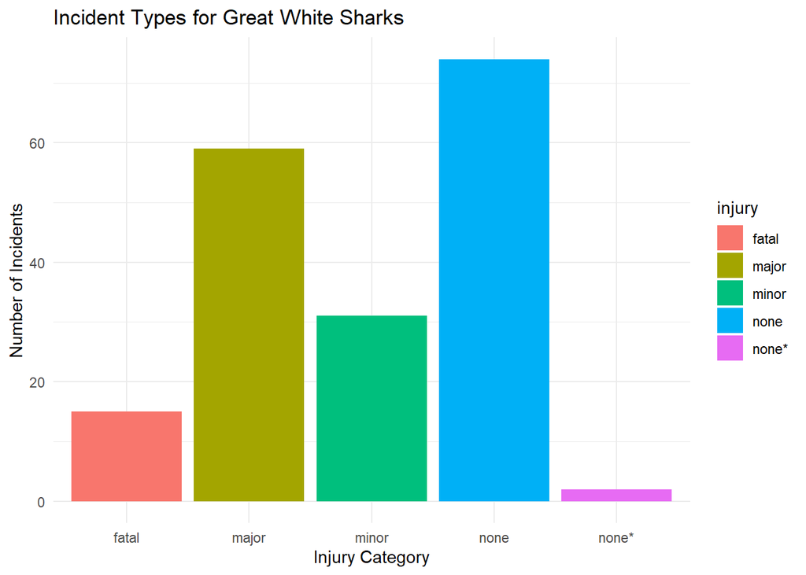

```r
sharks %>%
  filter(str_detect(species, "(?i)white")) %>%
  ggplot(aes(x = injury, fill = injury)) +
  geom_bar() +
  labs(
    title = "Incident Types for Great White Sharks",
    x = "Injury Category",
    y = "Number of Incidents"
  ) +
  theme_minimal()
```

## Knit and Upload

Please knit your work as an .html file and upload to Canvas. Homework is due before the start of the next lab. No late work is accepted. Make sure to use the formatting conventions of RMarkdown to make your report neat and clean!